# MP3

Fiona Miller, Starry Zhou, Morgan McLain-Smith

April 10, 2017

## Problem Statement

We worked on project 3: genre multiplicity. We wanted to see if there were any trends in the number of genres movies were labeled with between 1900 and 2016. To do this, we created two visualizations: a line chart with the average number of genres in movies each year, and a bar chart of the proportions of movies with each number of genres in a year.

## Find total number of films per year

```r
table2 <- db %>%
  dbGetQuery("SELECT id, production_year FROM title
             WHERE kind_id = 1;")

table3 <- table2%>%
  select(production_year)%>%
  group_by(production_year) %>%
  summarise(num_films = sum(n()))

table4 <- table3 %>%
  mutate(total=sum(num_films))
```

## Find total number of genres per year

```r
movieGenreAndYear <- db %>%
  dbGetQuery("SELECT mi.movie_id, mi.info, t.production_year
              FROM movie_info mi
              INNER JOIN title t ON t.id = mi.movie_id
              WHERE mi.info_type_id = 3
                    AND t.kind_id = 1;")
# "movie_info_info_type_id_exists" indexes "movie_info.info_type_id", "title_kind_id_exists" indexes "title.kind_id"

t3 <- movieGenreAndYear %>%
  group_by(production_year) %>%
  summarise(num_genre = n())
```

## Find average number of genres for a movie per year

```r
g1 <- t3 %>%
  inner_join(table3, by = "production_year")

g2 <- g1 %>%
  mutate(avg_genre = num_genre/num_films)

g3<- g2%>%
  filter(production_year>=1900,production_year<=2016)
```

## Graph showing average number of genres for a film per year

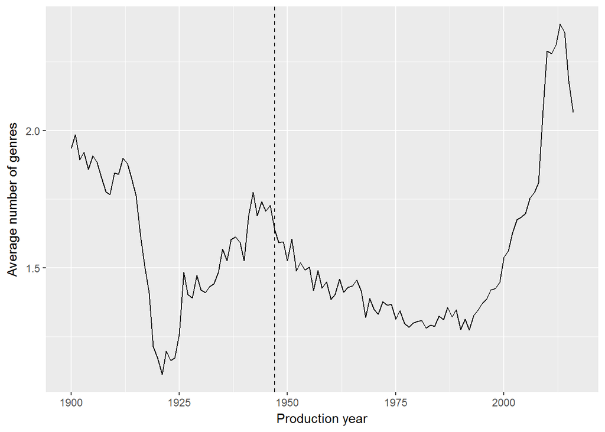

```r
vis <- ggplot(g3, aes(x=production_year,y=avg_genre))+
geom_line(aes(fill = avg_genre))+
  geom_vline(xintercept = 1947, linetype=2)+
  scale_x_continuous(name="Production year")+
  scale_y_continuous(name="Average number of genres")
vis
```

## The spread of movies with different numbers of genres each year

```r
numGenrePerMovieByYear <- movieGenreAndYear%>%
  group_by(movie_id, production_year) %>%
  summarize(genresPerMovie = n()) %>%
  ungroup() %>%
  group_by(production_year, genresPerMovie) %>%
  summarize(countMovies = n()) %>%
  filter(production_year<=2016, production_year>=1900)%>%
  mutate(genresPerMovie = factor(genresPerMovie, levels = 15:1))
```

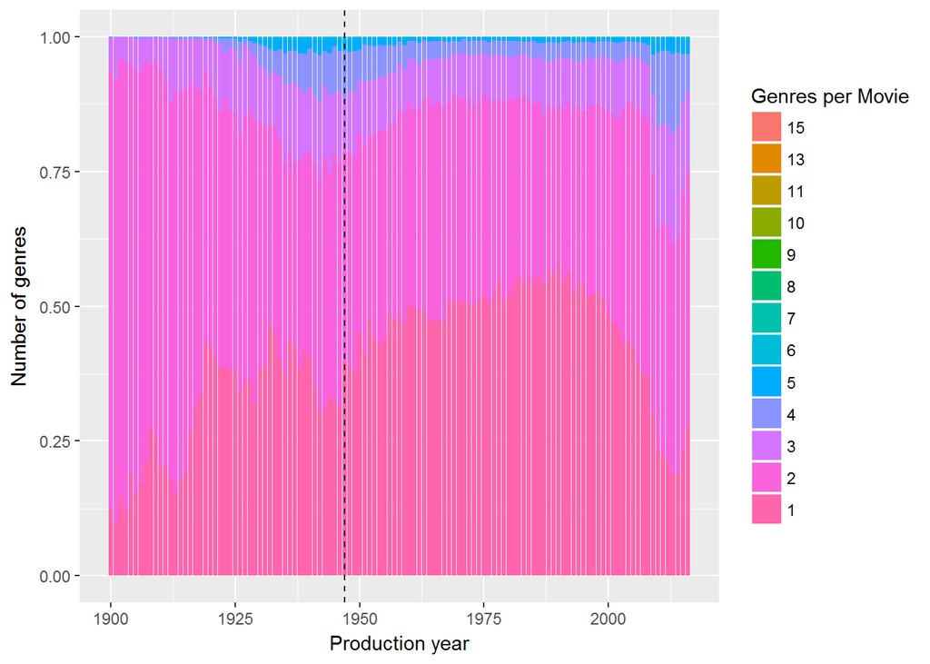

```r
ggplot( numGenrePerMovieByYear, aes(x= production_year, y = countMovies, fill = genresPerMovie))+
  geom_bar(position = "fill", stat="identity")+
  geom_vline(xintercept = 1947, linetype=2)+
scale_x_continuous(name="Production year")+
  scale_y_continuous(name="Number of genres")+
  scale_fill_discrete(name="Genres per Movie")
```

## Explanation

We expected to see a major change after 1947, as the major antitrust Paramount Pictures case was decided in 1948. While the averages genres in a movie did decrease after this case, this decrease appears consistent with a downward trend established several years before the decision.

From the bar chart, we can see that genre multiplicity is hardly a new phenomenon. In there very early days, films were much more likely to have 2 genres than to have just one. There are several other trends apparent in this graph. First, the majority of movies have always had 1-2 genres. The proportion of movies with 3 genres is much smaller than that with 1 or 2, but has remained fairly consistent over the years. Movies with 4+ were almost unheard of before the 20s, became more common around the Golden Age of Hollywood, then became less common, and then experienced a spike in the 2010s.However there is one movie that was labelled with 15 genres, which is the reason that the second visualization has a key that goes up until 15.

Given the increasing averages fairly gradual start, we were unable to attribute it to any single event. While it’s drop off was dramatic, we were similarly unable to attribute it to anything. It seems that the changes are gradual and unpredictable.